# Exercises - day 2

Benjamin Skov Kaas-Hansen

4/28/2020

## 0. Initialise

```r
for (p in c("tidyverse", "ggplot2", "broom"))
    library(p, character.only = TRUE)

seed <- 42
set_seed <- function() set.seed(seed)
```

# Understanding Bayesian analysis by hand

## 1. Run code

```r
n_sim <- 10000 # No. samples to generate (NB! more than in exercises)
sample_size <- 84 # The sample size (horoscopes)
observed_succes <- 27 # No. of observed correct guesses

theta <- runif(n_sim) # Random draw from (flat) prior
res <- rbinom(n_sim, size = sample_size, prob = theta)
    # Conditional draws from likelihood
keep <- theta[res == observed_succes]
    # Theta values that match observations (= posterior)
```

## 2. Plot histogram

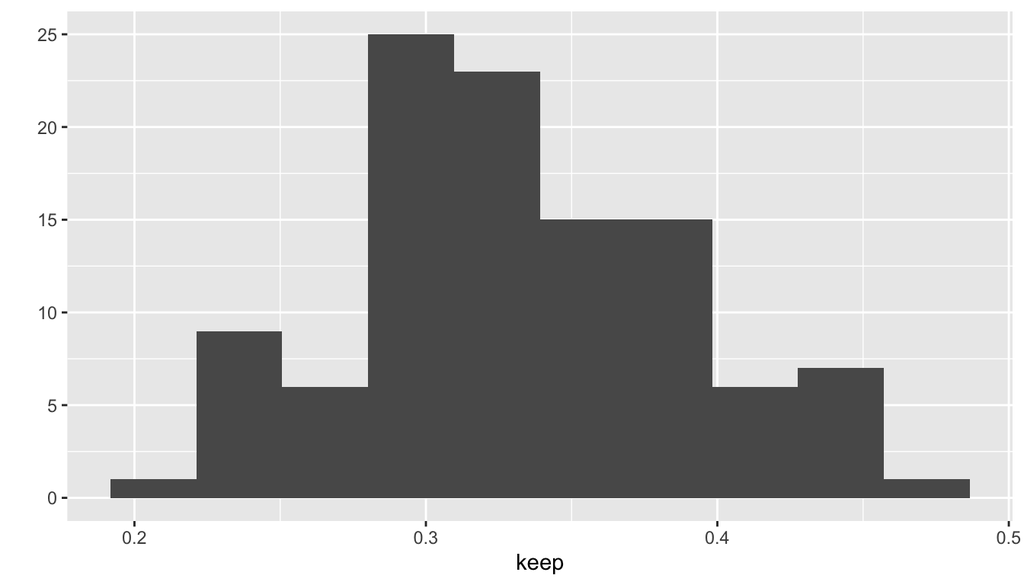

```r
qplot(keep, geom = "histogram", bins = 10)
```

## 3. Median posterior and MAP

```r
find_mode <- function(x, n_digits = 3) { # helper function; finds mode of x
    x <- round(x, n_digits)
    ux <- unique(x)
    ux[which.max(tabulate(match(x, ux)))][1] # index in case of ties
}
```

```r
median(keep)
```

```
## [1] 0.329325
```

```r
find_mode(keep)
```

```
## [1] 0.332
```

## 4. Non-uniform prior

Using beta distribution (which is also conjugate prior to binomial distribution, obviating sampling)

```r
posterior_theta <- function(a, b, n = sample_size, k = observed_succes) {
    set_seed()
    theta <- rbeta(n_sim, a, b) # Random draw from beta prior
    set_seed()
    res <- rbinom(n_sim, size = n, prob = theta)
        # Conditional draws from likelihood
    return(theta[res == k])
        # Theta values that match observations (= posterior)
}

prior_theta_2_5 <- rbeta(n_sim, 2, 5)
post_theta_2_5 <- posterior_theta(2, 5)
```

## 5 + 6. Use non-flat prior

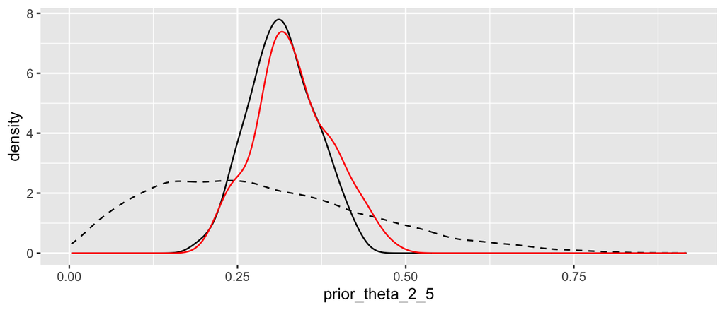

```r
ggplot() +
    stat_density(aes(x = prior_theta_2_5), geom = "line", linetype = 2) +
    stat_density(aes(x = post_theta_2_5), geom = "line") +
    stat_density(aes(x = keep), geom = "line", colour = "red")
```

```r
find_mode(post_theta_2_5)
```

```
## [1] 0.32
```

## 8. Comparison with flat prior

Not very big difference.

## 9. Effective samples

Quite few samples are carried over, low effective sample size => unstable estimates (especially interval bounds).

```r
length(post_theta_2_5)
```

```
## [1] 231
```

```r
scales::percent(length(post_theta_2_5) / n_sim, 0.1)
```

```
## [1] "2.3%"
```

## 10. Larger sample

Data clearly dominate the prior to a greater extent when larger sample size.

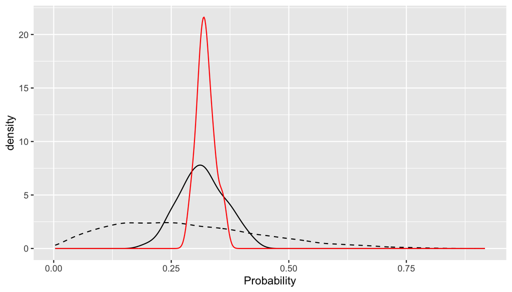

```r
ggplot() +
    stat_density(aes(x = prior_theta_2_5), geom = "line", linetype = 2) +
    stat_density(aes(x = post_theta_2_5), geom = "line") +
    stat_density(aes(x = posterior_theta(2, 5, 840, 270)), geom = "line", colour = "red") +
    labs(x = "Probability")
```

# Using rstanarm

## 0. Inititalise

```r
for (p in c("rstanarm", "bayesplot"))
    library(p, character.only = TRUE)

options(mc.cores = parallel::detectCores() - 1)

df <- tibble(correct = rep(0:1, times = c(84 - 27, 27)))
glimpse(df)
```

```
## Rows: 84
## Columns: 1
## $ correct <int> 0, 0, 0, 0, 0, 0, 0, 0, 0, 0, 0, 0, 0, 0, 0, 0, 0, 0, 0, 0, 0…
```

## 1. Using stan_glm()

```r
fit <- stan_glm(correct ~ 1, data = df, family = binomial)
```

```r
fit
```

```
## stan_glm
##  family:       binomial [logit]
##  formula:      correct ~ 1
##  observations: 84
##  predictors:   1
## ------
##             Median MAD_SD
## (Intercept) -0.8    0.2
##
## ------
## * For help interpreting the printed output see ?print.stanreg
## * For info on the priors used see ?prior_summary.stanreg
```

## 2. Extract posterior distribution

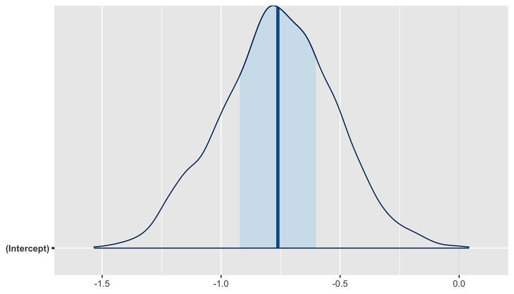

```r
post_draws <- as.data.frame(fit)
mcmc_areas(post_draws)
```

## 3. MAP and median posterior on probability scale

```r
expit <- function(x) exp(x) / (1 + exp(x)) # Inverse of logistic transformation
intercept <- post_draws[, 1]
scales::percent(median(expit(intercept)))
```

```
## [1] "32%"
```

```r
scales::percent(find_mode(expit(intercept))) # MAP
```

```
## [1] "32%"
```

## 4. Flat prior

```r
fit_flat_prior <- update(fit, prior_intercept = NULL)
```

```r
fit_flat_prior
```

```
## stan_glm
##  family:       binomial [logit]
##  formula:      correct ~ 1
##  observations: 84
##  predictors:   1
## ------
##             Median MAD_SD
## (Intercept) -0.8    0.2
##
## ------
## * For help interpreting the printed output see ?print.stanreg
## * For info on the priors used see ?prior_summary.stanreg
```

## 5. Non-flat prior

```r
fit_nonflat_prior <- update(fit, prior_intercept = normal(0, 0.1))
```

```r
fit_nonflat_prior
```

```
## stan_glm
##  family:       binomial [logit]
##  formula:      correct ~ 1
##  observations: 84
##  predictors:   1
## ------
##             Median MAD_SD
## (Intercept) -0.1    0.1
##
## ------
## * For help interpreting the printed output see ?print.stanreg
## * For info on the priors used see ?prior_summary.stanreg
```

## 6. My own prior

```r
fit_own_prior <- update(fit, prior_intercept = cauchy(0, 4))
```

```r
fit_own_prior
```

```
## stan_glm
##  family:       binomial [logit]
##  formula:      correct ~ 1
##  observations: 84
##  predictors:   1
## ------
##             Median MAD_SD
## (Intercept) -0.8    0.2
##
## ------
## * For help interpreting the printed output see ?print.stanreg
## * For info on the priors used see ?prior_summary.stanreg
```

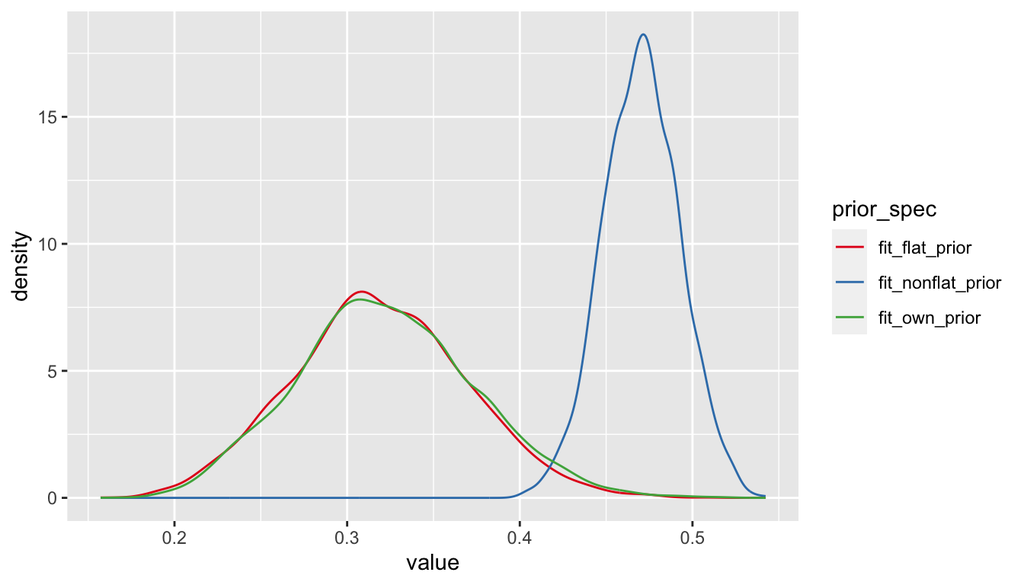

```r
small_sample_posteriors <- sapply(c("fit_flat_prior", "fit_nonflat_prior", "fit_own_prior"),
       function(.) expit(as.data.frame(get(.))[, 1])) %>%
    as.data.frame() %>%
    gather(prior_spec, value) %>%
    mutate(n_sample = 84)

ggplot(small_sample_posteriors, aes(x = value, colour = prior_spec)) +
    stat_density(geom = "line", position = "identity") +
    scale_colour_brewer(palette = "Set1")
```

## 7. Larger sample

Output on next page.

```r
df2 <- tibble(correct = rep(0:1, times = c(840 - 270, 270)))
for (f in c("fit_flat_prior", "fit_nonflat_prior", "fit_own_prior")) {
    assign(paste0(f, "_larger"), update(get(f), data = df2))
}

large_sample_posteriors <- sapply(grep("prior_larger", ls(), value = TRUE),
       function(.) expit(as.data.frame(get(.))[, 1])) %>%
    as.data.frame() %>%
    gather(prior_spec, value) %>%
    mutate(n_sample = 840)
```

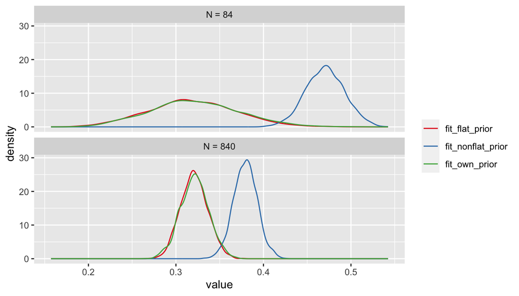

```r
bind_rows(small_sample_posteriors, large_sample_posteriors) %>%
    ggplot(aes(x = value, colour = str_remove(prior_spec, "\\_larger"))) +
        stat_density(geom = "line", position = "identity") +
        scale_colour_brewer(palette = "Set1") +
        guides(colour = guide_legend(title = NULL)) +
        facet_wrap(~ paste("N =", n_sample), ncol = 1)
```

# Relying on the prior

## 1. Frequentist analysis of P(failure)

The maximum likelihood estimator $\hat\theta$ (MLE) of a binomial variable with $k$ successes in $n$ trials is $\hat\theta = \frac{k}{n}$. Because $k = 0$, the MLE is zero, leaving no uncertainty, and so there’s no standard error, making it impossible to actually derive a confidence interval. So the forecast would be 0 failures.

## 2. Bayesian analysis of P(failure)

For a beta(a, b) prior and a binomial(k, n) likelihood, the posterior is beta(a + k, b + n - k), because the beta distribution is a conjugate prior to the binomial likelihood. Thus, `prop_failure` is the posterior distribution of the expected probability of producing a failed drug, assuming a beta(0.5, 0.5) prior (Jeffrey’s prior).

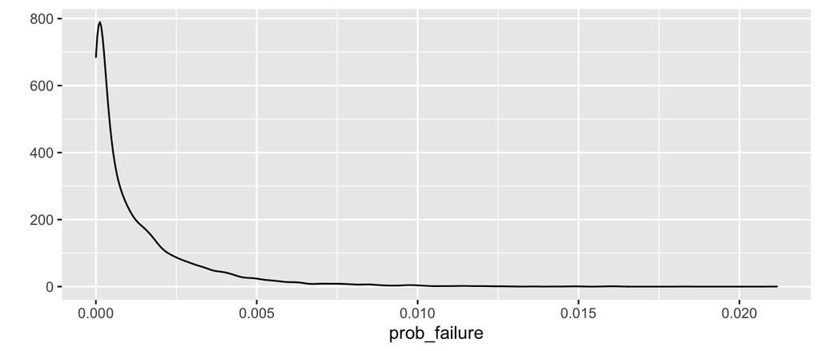

```r
prob_failure <- rbeta(10000, 0.5 + 0, 0.5 + 365)
qplot(prob_failure, geom = "density", trim = TRUE)
```

```r
scales::percent(median(prob_failure))
```

```
## [1] "0%"
```

```r
scales::percent(find_mode(prob_failure))
```

```
## [1] "0%"
```

Distribution of expected number of failures with 365 drugs produced.

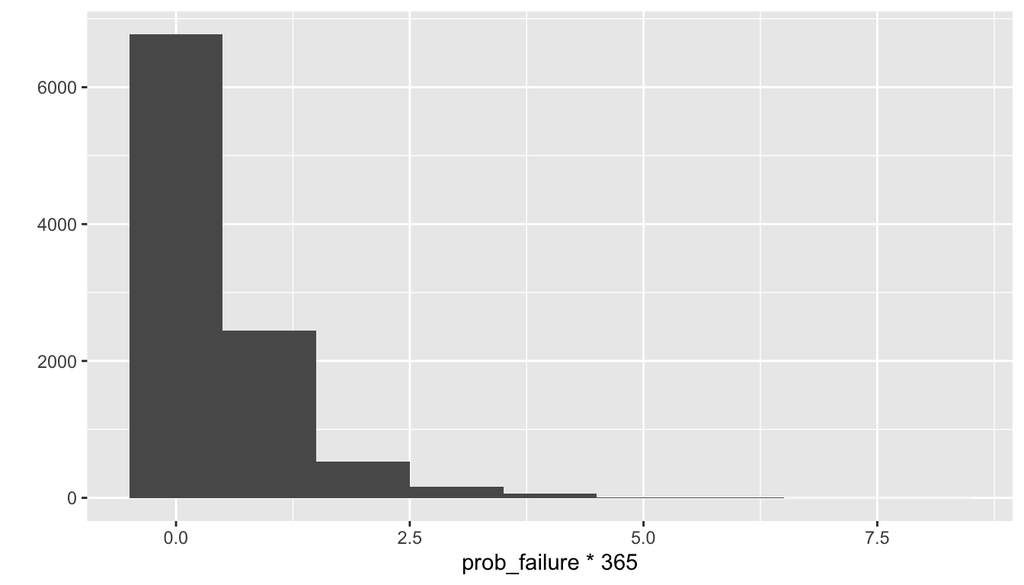

```r
qplot(prob_failure * 365, geom = "histogram", binwidth = 1)
```

# Multiple linear regression

## 1. Load data

```r
library("isdals")
data(fev)
glimpse(fev)
```

```
## Rows: 654
## Columns: 5
## $ Age    <int> 9, 8, 7, 9, 9, 8, 6, 6, 8, 9, 6, 8, 8, 8, 8, 7, 5, 6, 9, 9, 5,…
## $ FEV    <dbl> 1.708, 1.724, 1.720, 1.558, 1.895, 2.336, 1.919, 1.415, 1.987,…
## $ Ht     <dbl> 57.0, 67.5, 54.5, 53.0, 57.0, 61.0, 58.0, 56.0, 58.5, 60.0, 53…
## $ Gender <int> 0, 0, 0, 1, 1, 0, 0, 0, 0, 0, 0, 1, 0, 1, 1, 1, 1, 0, 1, 1, 0,…
## $ Smoke  <int> 0, 0, 0, 0, 0, 0, 0, 0, 0, 0, 0, 0, 0, 0, 0, 0, 0, 0, 0, 0, 0,…
```

## 2. Analyse with regular model

Smoking associated with decreased FEV.

```r
freq_fit <- lm(FEV ~ ., data = fev)
tidy(freq_fit)
```

```
## # A tibble: 5 x 5
##   term        estimate std.error statistic  p.value
##   <chr>          <dbl>     <dbl>     <dbl>    <dbl>
## 1 (Intercept)  -4.46     0.223      -20.0  1.07e-69
## 2 Age           0.0655   0.00949      6.90 1.21e-11
## 3 Ht            0.104    0.00476     21.9  4.98e-80
## 4 Gender        0.157    0.0332       4.73 2.74e- 6
## 5 Smoke        -0.0872   0.0593      -1.47 1.41e- 1
```

## 3.-5. Bayesian analysis

```r
bayes_fit <- stan_glm(FEV ~ ., data = fev, prior_intercept = normal(0, 1))
```

```r
shinystan::launch_shinystan(bayes_fit)
```

## 6. More and longer chains

```r
bayes_fit_more_longer <- update(bayes_fit, iter = 6000, chains = 8)
```

```r
bayes_fit_more_longer
```

```
## stan_glm
##  family:       gaussian [identity]
##  formula:      FEV ~ .
##  observations: 654
##  predictors:   5
## ------
##             Median MAD_SD
## (Intercept) -4.5    0.2
## Age          0.1    0.0
## Ht           0.1    0.0
## Gender       0.2    0.0
## Smoke       -0.1    0.1
##
## Auxiliary parameter(s):
##       Median MAD_SD
## sigma 0.4    0.0
##
## ------
## * For help interpreting the printed output see ?print.stanreg
## * For info on the priors used see ?prior_summary.stanreg
```

## 7. Smoking parameter

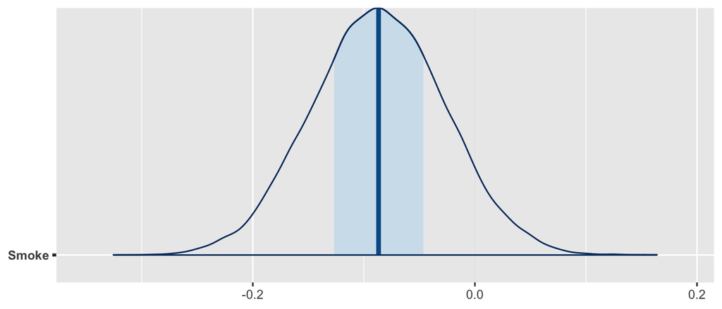

```r
mcmc_areas(as.data.frame(bayes_fit_more_longer), "Smoke")
```

P(smoking effect > 0)

```r
scales::percent(mean(as.data.frame(bayes_fit_more_longer)$Smoke > 0), 0.1)
```

```
## [1] "7.2%"
```

```r
knitr::opts_chunk$set(eval = FALSE)
```

## 8. Use `brms`

```r
library(brms)
brm_fit <- brm(FEV ~ ., data = fev)
```

Not big different from `summary([rstanarm_fit])`.

```r
brm_fit
```

## 9. Try `get_prior()`

```r
get_prior(FEV ~ ., data = fev)
```

## 10.-11. Set priors and re-run `brm`

```r
priors <- c(prior_string("normal(0, 2)", class = "b"),
            prior(normal(1, 2), class = b, coef = Ht),
            prior(cauchy(0, 2), class = "sigma"))
brm_fit_custom_priors <- update(brm_fit, prior = priors)
```

```r
brm_fit_custom_priors
```

## 12. LOOCV

```r
brm_fit_wo_smoke <- update(brm_fit_custom_priors, formula = ~ . - Smoke, newdata = fev)
```

```r
for (f in c("brm_fit_wo_smoke", "brm_fit", "brm_fit_custom_priors"))
    assign(f, add_criterion(get(f), c("loo", "waic")))

loo_compare(brm_fit_wo_smoke, brm_fit, brm_fit_custom_priors, criterion = "loo")
```

# Analysing data from the Titanic

## 1. Load data

```r
data("Titanic")
ship <- expand_table(Titanic)
```

## 2. Frequentist analysis

```r
glm(Survived ~ ., data = ship, family = "binomial")
```

## 3. Bayesian approach

```r
titanic_bayes <- stan_glm(Survived ~ ., data = ship, family = binomial)
```

Lower classes associated with lower prob. of survival. Women more likely to survive; children as well. Could put on numbers, but running out of time.

```r
summary(titanic_bayes)
get_prior(Survived ~ ., data = ship, family = binomial)
```

# Quasi-complete separation

## 1. Load data

```r
load(url("https://biostatistics.dk/teaching/advtopicsB/data/qsep.rda"))
glimpse(qsep)
```

## 2. Frequentist analysis

```r
freq_fit <- glm(y ~ x, data = qsep, family = "binomial")
summary(freq_fit)
```

## 3. Bayesian approach

```r
bayes_fit <- stan_glm(y ~ x, data = qsep, family = binomial)
```

```r
summary(bayes_fit)
```